# Index

**1. Data Load**  
**1.1 Merge Data**

**2. EDA (Exploratory Data Analysis)**  
**2.1 Structure of the Data**  
**2.2 Descriptive Stats**  
**2.3 Data Imbalance Check**  
**2.4 Check for missing values**  
**2.5 Feature Analysis**  
**2.5.1 Categorical Feature Analysis**  
**2.5.2 Numerical Features Analysis**  
**2.5.3 DateTime Features Analysis**

**2.6 Correlation Analysis**

**3. Data Standardization**  
**3.1 Dropping useless features based on EDA and Correlation**  
**3.2 Missing Value Imputation**  
**3.3 Train-Test spit**  
**3.4 Feature Encoding**

**4. Feature Selection**  
**4.1 For Numerical Data**  
**4.2 For Categorical Data**

**5. Build Data Matrix for Models**

**6. TSNE Visualization**

**7. Models**  
**7.1 Machine Learning Models**  
**7.1.1 Random Model**  
**7.1.1 Logistic Regression (SGD) with Hyperparameter Tuning**  
**7.1.3 Logistic Regression (Sklearn)**  
**7.1.4 KNN (K-Nearest Neighbors)**  
**7.1.5 Decision Tree Model**  
**7.1.6 Random Forest Model**  
**7.1.7 XGBoost Model**  
**7.2 Deep Learning Model**  
**7.2.1 Neural Network (ANN) Model**

**8. Comparison**

**9. Conclusion**

# Machine Learning Objective

```
1. Given betting data, build a high accuracy model for the Binary Classification for valid and invalid bets.
```

# Importing Libraries / Modules

```python
import pandas as pd
import numpy as np

%matplotlib inline
import matplotlib.pyplot as plt
import matplotlib.ticker as mticker
import seaborn as sns

from datetime import date
from datetime import datetime

from scipy import stats
from scipy.special import boxcox, inv_boxcox

import math
```

```python
import start
```

```
Initial setup completed.
```

```python
from helper import *
```

```
Helper Imported.
```

# 1. Load Data

```python
valid_data = pd.read_json (r'validbets.json')
invalid_data = pd.read_json (r'invalidbets.json')
```

```python
valid_data.head(3)
```

|  | _id | stake | type | placedDate | horse | betRate | marketId | IP | eventType | userName | selectionName | marketName | event | averagePriceMatched | status | winnerId |
| --- | --- | --- | --- | --- | --- | --- | --- | --- | --- | --- | --- | --- | --- | --- | --- | --- |
| 0 | 60337ca8cc80710087ff5d8c | 500.000 | BACK | 2021-02-22T09:43:04.686Z | 8776882 | 1.020 | 1.180 | 2401:4900:30e5:71f1:a86c:d186:5d52:3fa8 | Tennis | brovinn | Danielle Rose Collins | Match Odds | Saisai Zheng v Danielle Rose Collins | 1.020 | WINNER_DECLARED | 8776882 |
| 1 | 60337d5dcc80710087ff5d90 | 2100.000 | LAY | 2021-02-22T09:46:05.458Z | 8776882 | 1.010 | 1.180 | 49.36.123.125 | Tennis | aksash111 | Danielle Rose Collins | Match Odds | Saisai Zheng v Danielle Rose Collins | 1.010 | WINNER_DECLARED | 8776882 |
| 2 | 60337b0a13046300869b42c4 | 25000.000 | LAY | 2021-02-22T09:36:10.372Z | 8776882 | 1.060 | 1.180 | 2405:201:25:d0aa:11b4:2e1c:9999:f32a | Tennis | pinka2 | Danielle Rose Collins | Match Odds | Saisai Zheng v Danielle Rose Collins | 1.050 | WINNER_DECLARED | 8776882 |

```python
print("Valid Data Shape : ",valid_data.shape)
print("No. of Data points : ", valid_data.shape[0])
print("No. of Fetures : ", valid_data.shape[1]-1)
```

```
Valid Data Shape :  (10000, 16)
No. of Data points :  10000
No. of Fetures :  15
```

```python
invalid_data.head(3)
```

|  | _id | stake | type | placedDate | horse | betRate | marketId | IP | eventType | userName | selectionName | marketName | event | averagePriceMatched | status | winnerId |
| --- | --- | --- | --- | --- | --- | --- | --- | --- | --- | --- | --- | --- | --- | --- | --- | --- |
| 0 | 5fa47215305f1f00f02b5ae4 | 783758 | LAY | 2020-11-05T21:43:49.222Z | 127991 | 160.000 | 1.175 | 185.105.2.158 | Soccer | contra11 | AC Milan | Match Odds | AC Milan v Lille | 160.000 | INVALID_BET | 44790 |
| 1 | 5fa014d9d1a79f00d41349df | 4500 | BACK | 2020-11-02T14:16:57.494Z | 22121561 | 1.960 | 1.175 | 106.204.14.80 | Cricket | sirsa3 | Delhi Capitals | Match Odds | Delhi Capitals v Royal Challengers Bangalore | 1.970 | INVALID_BET | 22121561 |
| 2 | 5fa014db5a7a0a00e2868190 | 7000 | BACK | 2020-11-02T14:16:59.763Z | 22121561 | 1.960 | 1.175 | 185.203.122.18 | Cricket | bhush001 | Delhi Capitals | Match Odds | Delhi Capitals v Royal Challengers Bangalore | 1.960 | INVALID_BET | 22121561 |

```python
print("Invalid Data Shape : ",invalid_data.shape)
print("No. of Data points : ", invalid_data.shape[0])
print("No. of Fetures : ", invalid_data.shape[1]-1)
```

```
Invalid Data Shape :  (66, 16)
No. of Data points :  66
No. of Fetures :  15
```

## 1.1 Merge Data

```python
merged_data = pd.concat([valid_data,invalid_data])
```

```python
merged_data.head(3)
```

|  | _id | stake | type | placedDate | horse | betRate | marketId | IP | eventType | userName | selectionName | marketName | event | averagePriceMatched | status | winnerId |
| --- | --- | --- | --- | --- | --- | --- | --- | --- | --- | --- | --- | --- | --- | --- | --- | --- |
| 0 | 60337ca8cc80710087ff5d8c | 500.000 | BACK | 2021-02-22T09:43:04.686Z | 8776882 | 1.020 | 1.180 | 2401:4900:30e5:71f1:a86c:d186:5d52:3fa8 | Tennis | brovinn | Danielle Rose Collins | Match Odds | Saisai Zheng v Danielle Rose Collins | 1.020 | WINNER_DECLARED | 8776882 |
| 1 | 60337d5dcc80710087ff5d90 | 2100.000 | LAY | 2021-02-22T09:46:05.458Z | 8776882 | 1.010 | 1.180 | 49.36.123.125 | Tennis | aksash111 | Danielle Rose Collins | Match Odds | Saisai Zheng v Danielle Rose Collins | 1.010 | WINNER_DECLARED | 8776882 |
| 2 | 60337b0a13046300869b42c4 | 25000.000 | LAY | 2021-02-22T09:36:10.372Z | 8776882 | 1.060 | 1.180 | 2405:201:25:d0aa:11b4:2e1c:9999:f32a | Tennis | pinka2 | Danielle Rose Collins | Match Odds | Saisai Zheng v Danielle Rose Collins | 1.050 | WINNER_DECLARED | 8776882 |

```python
print("Data Shape : ",merged_data.shape)
print("No. of Data points : ", merged_data.shape[0])
print("No. of Fetures : ", merged_data.shape[1]-1)
```

```
Data Shape :  (10066, 16)
No. of Data points :  10066
No. of Fetures :  15
```

```python
heading('Backup copy of Data')
original_data = merged_data.copy()
print("Data Shape : ",original_data.shape)
print("No. of Data points : ", original_data.shape[0])
print("No. of Fetures : ", original_data.shape[1]-1)
```

```
-------------------
Backup copy of Data
-------------------
Data Shape :  (10066, 16)
No. of Data points :  10066
No. of Fetures :  15
```

#### Save dataframe to csv file.

```python
merged_data.to_csv('merge_data.csv', index=False)
```

# 2. EDA (Exploratory Data Analysis)

## 2.1 Structure of the data

```python
merged_data.info()
```

```
<class 'pandas.core.frame.DataFrame'>
Int64Index: 10066 entries, 0 to 65
Data columns (total 16 columns):
 #   Column               Non-Null Count  Dtype
---  ------               --------------  -----
 0   _id                  10066 non-null  object
 1   stake                10066 non-null  float64
 2   type                 10066 non-null  object
 3   placedDate           10066 non-null  object
 4   horse                10066 non-null  int64
 5   betRate              10066 non-null  float64
 6   marketId             10066 non-null  float64
 7   IP                   10063 non-null  object
 8   eventType            10066 non-null  object
 9   userName             10066 non-null  object
 10  selectionName        10066 non-null  object
 11  marketName           10066 non-null  object
 12  event                10066 non-null  object
 13  averagePriceMatched  10066 non-null  float64
 14  status               10066 non-null  object
 15  winnerId             10066 non-null  int64
dtypes: float64(4), int64(2), object(10)
memory usage: 1.3+ MB
```

### Observation :

- **IP** column have 3 missing values.
- **placedDate** needs to convert into datetime format.

### 2.2 Descriptive Stats

```python
describe(merged_data).T
```

```
----------------------
Descriptive statistics
----------------------
```

|  | count | mean | std | min | 25% | 50% | 75% | max | skew | kurt |
| --- | --- | --- | --- | --- | --- | --- | --- | --- | --- | --- |
| stake | 10066.000 | 31709.479 | 145600.465 | 9.000 | 400.000 | 2000.000 | 20000.000 | 9300000.000 | 31.301 | 1723.736 |
| horse | 10066.000 | 4990883.972 | 4913718.664 | 235.000 | 1222344.000 | 4294272.000 | 9628997.250 | 36846168.000 | 1.136 | 1.190 |
| betRate | 10066.000 | 2.452 | 13.855 | 1.010 | 1.180 | 1.400 | 1.670 | 1000.000 | 44.571 | 2835.808 |
| marketId | 10066.000 | 1.179 | 0.001 | 1.175 | 1.179 | 1.179 | 1.180 | 1.180 | -1.300 | 0.975 |
| averagePriceMatched | 10066.000 | 2.466 | 13.969 | 1.010 | 1.180 | 1.400 | 1.670 | 1000.000 | 43.882 | 2754.245 |
| winnerId | 10066.000 | 4775882.844 | 4712822.120 | 235.000 | 1221386.000 | 4294272.000 | 9630879.000 | 36846168.000 | 1.029 | 0.602 |

### Observation :

- **stake** have **high standard deviation**, it indicates data are **more spread** out from the **mean**.
- **stake, betRate, averagePriceMatched** have **high positive skew value**, indicates **trail dragging towards the right** in their respective distributions.
- **stake, betRate, averagePriceMatched** also have **high positive kurt value**, as trail higher kurtosis corresponds to greater extremity of deviations (or outliers).

## 2.3 Data Imbalance Check

```python
merged_data['status'].value_counts()
```

```
WINNER_DECLARED    10000
INVALID_BET           66
Name: status, dtype: int64
```

```python
def pie_labeling(x):
    print(x)
    return '{:.4f}%\n(#{:.0f})'.format(x, sums.values.sum()*x/100)
```

```
99.3443250656128
0.6556725595146418
```

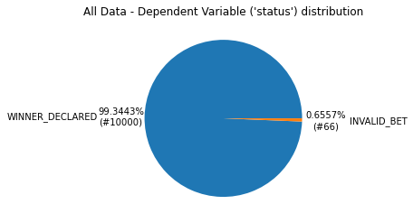

```python
from matplotlib.pyplot import pie, axis, show
sums = merged_data['status'].value_counts()
axis('equal')
pie(sums.values, labels=sums.index, autopct=pie_labeling, pctdistance=1.3, labeldistance=1.6)
plt.title("All Data - Dependent Variable ('status') distribution")

plt.show()
```

Observation :

- Data is highly **imbalanced**.
- **99.34%** data points belongs to **WINNER_DECLARED** while only **0.66%** belongs to **INVALID_BET** category.
- **Imbalanced Dataset** is primarily challenging as a predictive modeling task because of the **severely skewed class distribution**. This is the **cause** for **poor performance** with traditional machine learning models and evaluation metrics that assume a balanced class distribution.
- In the case of **class imbalance problems**,
  - The algorithm will be **more biased towards predicting the majority class** .
  - The algorithm will not have **enough data to learn the patterns present in the minority class**.
- Needs imbalance handling using either any one of them,
  - **Random Under-Sampling** (Drop majority class points to make data balanced).
    - It can discard useful information about the data itself which could be necessary for building rule-based classifiers such as Random Forests.
    - So we not perform Under-Sampling.
  - **Random Over-Sampling** (Increase the instances corresponding to the minority class by replicating them up to a constant degree to make data balanced).
    - It increases the **likelihood of overfitting** since it replicates the minority class events.
  - **Upsampling technique (e.g. SMOTE-Synthetic Minority Oversampling Technique)**
    - SMOTE is an **oversampling method** which creates **“synthetic”** example rather than oversampling by replacements.
    - SMOTE does not take into **consideration neighboring examples** can be from **other classes**. This can **increase the overlapping of classes** and can introduce **additional noise**.
  - Sklearn **class weight='balanced'** method.
    - It **doesn't make the dataset balanced**.
    - It **doesn't create new data**.
    - **Class weights** directly **modify the loss function** by giving **more (or less) penalty** to the **classes** with **more (or less) weight**.
- We use Sklearn **class weight='balanced'** method.

## 2.4 Check for missing values

```python
merged_data.isnull().values.any()
```

```
True
```

```python
missing_values_table(merged_data)
```

```
Dataframe has 16 columns.
There are 1 columns that have missing values.
```

|  | Missing Values | % of Total Values |
| --- | --- | --- |
| IP | 3 | 0.000 |

### Observation :

- **IP** feature have **3 missing values**.
- We can perform **Missing Data imputation Techniques** or **drop the missing values rows**.
- Since we have **small data**, we will not drop any missing value.
- we will deal it later using **Missing Data imputation Techniques**.

## 2.5 Feature Analysis

```python
heading("Number of unique values in each feature")
print(merged_data.nunique())
```

```
---------------------------------------
Number of unique values in each feature
---------------------------------------
_id                    10066
stake                    376
type                       2
placedDate             10063
horse                    319
betRate                  258
marketId                 390
IP                      1070
eventType                  3
userName                 410
selectionName            318
marketName                10
event                    245
averagePriceMatched      726
status                     2
winnerId                 195
dtype: int64
```

```python
categorical_list = ['type', 'horse', 'marketId', 'IP', 'eventType', 'userName', 'selectionName', 'marketName', 'event','winnerId']
numerical_list = ['stake', 'betRate', 'averagePriceMatched']
datetime_list = ['placedDate']
```

## Feature Analysis : _id

```python
merged_data['_id'].nunique()
```

```
10066
```

### Observation :

- Since **_id** is a **unique identifier** for data points, it should not be used in the modeling.
- We will not include it in modeling.

## 2.5.1 Categorical Features Analysis

```python
heading("Categorical Features")
print('\n'.join(categorical_list))
```

```
--------------------
Categorical Features
--------------------
type
horse
marketId
IP
eventType
userName
selectionName
marketName
event
winnerId
```

## 2.5.1.1 Feature Analysis : type

```python
merged_data['type'].value_counts()
```

```
LAY     5303
BACK    4763
Name: type, dtype: int64
```

```
----------------------------
type grouped by status Count
----------------------------
```

| status type | INVALID_BET | WINNER_DECLARED |
| --- | --- | --- |
| BACK | 35 | 4728 |
| LAY | 31 | 5272 |

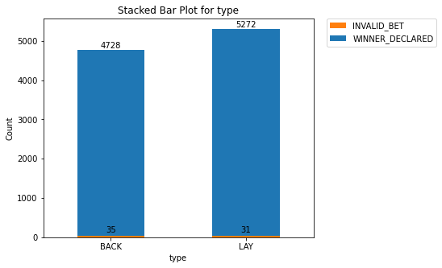

```python
crosstab_by_y_plot(merged_data, 'type', figsize=(6,5))
```

### Observation :

- Both type : **BACK** and **LAY** category are almost equally distributed for both classes (WINNER_DECLARED and INALID_BET).

## 2.5.1.2 Feature Analysis : horse

```python
print('No. of unique values of horse :', merged_data['horse'].nunique())
```

```
No. of unique values of horse : 319
```

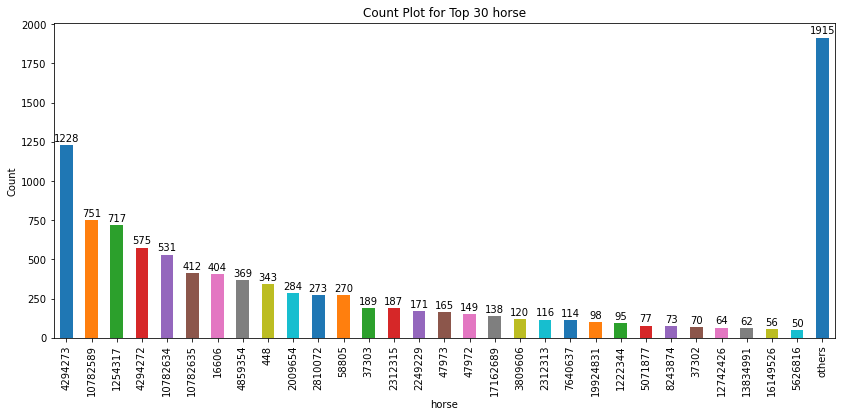

```python
count_plot(merged_data, 'horse')
```

### Observation :

- Only some horse have more bets more than 100, while others have of them bets less than 50 times.
- horse **4294273** bets **1228** times which is significantly higher than any other.

## 2.5.1.3 Feature Analysis : marketId

```python
merged_data['marketId']
```

```
0    1.180
1    1.180
2    1.180
3    1.180
4    1.180
      ...
61   1.179
62   1.179
63   1.177
64   1.177
65   1.179
Name: marketId, Length: 10066, dtype: float64
```

```python
print("No. of unique marketId :",merged_data['marketId'].nunique())
```

```
No. of unique marketId : 390
```

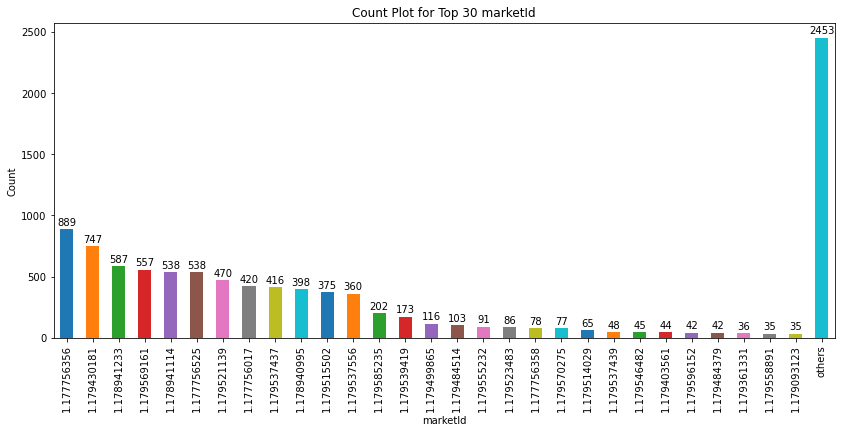

```python
count_plot(merged_data, 'marketId')
```

### Observation :

- 16 marketId's are repeated more than 100 times.
- Since **matketId** should be **categorical**, but it is more like **numerical data**.
- So we do **numeric analysis** for **marketId**.

```python
describe(merged_data['marketId'])
```

```
----------------------
Descriptive statistics
----------------------
```

|  | count | mean | std | min | 25% | 50% | 75% | max | skew | kurt |
| --- | --- | --- | --- | --- | --- | --- | --- | --- | --- | --- |
| marketId | 10066.000 | 1.179 | 0.001 | 1.175 | 1.179 | 1.179 | 1.180 | 1.180 | -1.300 | 0.975 |

```
-------------------------------------
Box Plot and Violin Plot for marketId
-------------------------------------
```

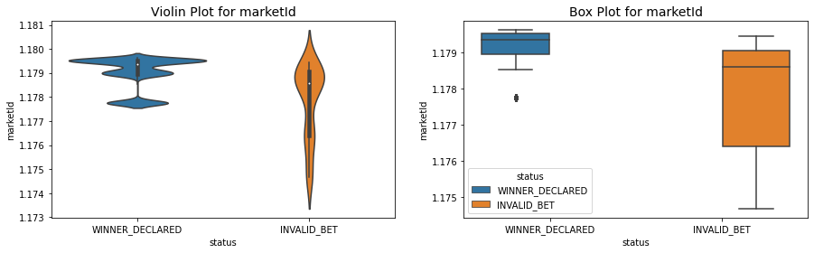

```python
box_violin_plot(merged_data, 'marketId')
```

### Observation :

- Violin plot and Box plot shows **different distribution** and **less overlapping** for **WINNER_DECARED** and **INVALID_BET**, so this feature can be **helpful** for the model to distinguish between 2 classes.

```
--------------------------
Distribution Plot marketId
--------------------------
```

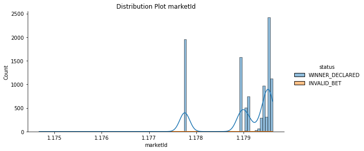

```python
displot(merged_data, 'marketId')
```

### Observation :

- marketId is **left skewed**.

## 2.5.1.4 Feature Analysis : IP

**IP have 3 missing values.**

```python
merged_data['IP']
```

```
0     2401:4900:30e5:71f1:a86c:d186:5d52:3fa8
1                               49.36.123.125
2        2405:201:25:d0aa:11b4:2e1c:9999:f32a
3     2401:4900:30e5:71f1:a86c:d186:5d52:3fa8
4     2401:4900:30e5:71f1:a86c:d186:5d52:3fa8
                       ...
61                            106.207.179.134
62                             103.200.84.188
63                            103.212.156.208
64                              124.253.0.211
65     2001:8f8:1a63:d2a1:ac87:4f9c:69c9:509e
Name: IP, Length: 10066, dtype: object
```

```python
print("No. of unique IP :",merged_data['IP'].nunique())
```

```
No. of unique IP : 1070
```

```python
crosstab_by_y_table(merged_data, 'IP')
```

```
--------------------------------------------
Top 10 IP by WINNER_DECLARED and INVALID_BET
--------------------------------------------
```

| status IP | WINNER_DECLARED |
| --- | --- |
| 182.64.30.119 | 346 |
| 139.5.236.244 | 282 |
| 49.36.123.125 | 276 |
| 171.79.58.20 | 164 |
| 2.49.87.166 | 161 |
| 49.156.123.116 | 126 |
| 103.15.54.35 | 124 |
| 43.248.68.89 | 110 |
| 124.253.0.211 | 108 |
| 103.43.250.201 | 104 |

| status IP | INVALID_BET |
| --- | --- |
| 157.38.56.125 | 3 |
| 5.30.174.173 | 3 |
| 106.202.47.158 | 3 |
| 122.162.233.121 | 2 |
| 103.200.84.188 | 2 |
| 101.0.34.127 | 2 |
| 183.83.43.165 | 2 |
| 183.83.42.241 | 2 |
| 106.202.25.23 | 2 |
| 2409:4052:208b:8ee:8175:5c7a:d025:3983 | 2 |

### Observation :

- Data have total **1070 unique IP's** out of 10066 bet records.
- Since **IP** is also a **unique identifier** not any type or class it should not be use as a **categorical feature**, so we will perform **feature engineering** on **IP**.

### Feature Engineering on IP

### Add Geological Information from IP

- We are adding **geological information** using **IP**.
  1. **city**
  2. **region**
  3. **country**
  4. **loc ('Latitude', 'Longitude')**
  5. **org (Internet Service Provider)**
  6. **postal code**
  7. **timezone**

  This information is gathered using **online service**, and information is depends upon the service provider.  
  These features can be useful in prediction if there is any **geological correlation exists**.

**Note :** **"ip_Details_splitted.csv"** is created using online service for the unique IP's in the data set.

we **merge** this information into dataset.

```python
map_data = pd.read_csv('ip_Details_splitted.csv')
```

```python
merged_data = pd.merge(merged_data, map_data, left_on=  ['IP'],
                   right_on= ['IP'],
                   how = 'left')
```

```python
lat_lon_df = merged_data["loc"].str.split(",", n = 1, expand = True)
lat_lon_df.columns = ['Latitude', 'Longitude']
```

```python
merged_data = pd.concat([merged_data, lat_lon_df], axis=1)
```

```python
merged_data.head(3)
```

|  | _id | stake | type | placedDate | horse | betRate | marketId | IP | eventType | userName | selectionName | marketName | event | averagePriceMatched | status | winnerId | Details | city | region | country | loc | org | postal | timezone | Latitude | Longitude |
| --- | --- | --- | --- | --- | --- | --- | --- | --- | --- | --- | --- | --- | --- | --- | --- | --- | --- | --- | --- | --- | --- | --- | --- | --- | --- | --- |
| 0 | 60337ca8cc80710087ff5d8c | 500.000 | BACK | 2021-02-22T09:43:04.686Z | 8776882 | 1.020 | 1.180 | 2401:4900:30e5:71f1:a86c:d186:5d52:3fa8 | Tennis | brovinn | Danielle Rose Collins | Match Odds | Saisai Zheng v Danielle Rose Collins | 1.020 | WINNER_DECLARED | 8776882 | ['Delhi', 'Delhi', 'IN', '28.6519,77.2315', 'AS45609 Bharti Airtel Ltd. AS for GPRS Service', '1... | Delhi | Delhi | IN | 28.6519,77.2315 | AS45609 Bharti Airtel Ltd. AS for GPRS Service | 110001 | Asia/Kolkata | 28.6519 | 77.2315 |
| 1 | 60337d5dcc80710087ff5d90 | 2100.000 | LAY | 2021-02-22T09:46:05.458Z | 8776882 | 1.010 | 1.180 | 49.36.123.125 | Tennis | aksash111 | Danielle Rose Collins | Match Odds | Saisai Zheng v Danielle Rose Collins | 1.010 | WINNER_DECLARED | 8776882 | ['Mumbai', 'Maharashtra', 'IN', '19.0728,72.8826', 'AS55836 Reliance Jio Infocomm Limited', '400... | Mumbai | Maharashtra | IN | 19.0728,72.8826 | AS55836 Reliance Jio Infocomm Limited | 400070 | Asia/Kolkata | 19.0728 | 72.8826 |
| 2 | 60337b0a13046300869b42c4 | 25000.000 | LAY | 2021-02-22T09:36:10.372Z | 8776882 | 1.060 | 1.180 | 2405:201:25:d0aa:11b4:2e1c:9999:f32a | Tennis | pinka2 | Danielle Rose Collins | Match Odds | Saisai Zheng v Danielle Rose Collins | 1.050 | WINNER_DECLARED | 8776882 | ['Airoli', 'Maharashtra', 'IN', '19.1167,72.9833', 'AS55836 Reliance Jio Infocomm Limited', '400... | Airoli | Maharashtra | IN | 19.1167,72.9833 | AS55836 Reliance Jio Infocomm Limited | 400701 | Asia/Kolkata | 19.1167 | 72.9833 |

### Image generated using Tableau

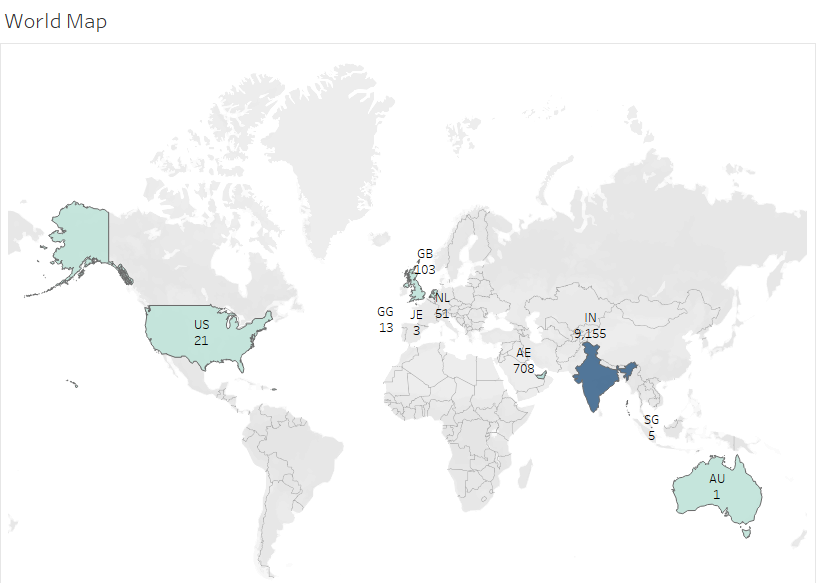

```python
display_image('world.png', width=600)
```

## Observation :

- **Most** of the bets are placed in **INDIA** total **9155**.
- **Second most** bets are placed from **AE (United Arab Emirates)** total **708**.
- **Third** one is **GB (United Kingdom of Great Britain)** with **103** bets.

```python
crosstab_by_y_table(merged_data, 'city', y_both=True)
```

```
----------------------------------------------
Top 10 city by WINNER_DECLARED and INVALID_BET
----------------------------------------------
```

| status city | INVALID_BET | WINNER_DECLARED |
| --- | --- | --- |
| Mumbai | 3 | 2509 |
| Delhi | 16 | 1682 |
| Airoli | 3 | 982 |
| Ludhiāna | 6 | 716 |
| Dubai | 6 | 685 |
| Jaipur | 8 | 419 |
| Surat | 0 | 392 |
| Gurgaon | 1 | 292 |
| Ahmedabad | 1 | 283 |
| Kolkata | 0 | 190 |

| status city | INVALID_BET | WINNER_DECLARED |
| --- | --- | --- |
| Delhi | 16 | 1682 |
| Jaipur | 8 | 419 |
| Ludhiāna | 6 | 716 |
| Dubai | 6 | 685 |
| Hyderabad | 4 | 162 |
| Mumbai | 3 | 2509 |
| Airoli | 3 | 982 |
| Guntur | 2 | 0 |
| Mohali | 2 | 59 |
| Bengaluru | 2 | 23 |

### Observation :

- **Mumbai** is where from **most** of the bets are placed.
- **Delhi** is the **second most** but have **high INVALID_BET** in compare to others.
- Since data belongs to betting, **geological information** can be useful since a **group of people** can bet and they may have correlation between them by their geological location.

## 2.5.1.5 Feature Analysis : eventType

```python
# merged_data['eventType'].value_counts()
```

```
---------------------------------
eventType grouped by status Count
---------------------------------
```

| status eventType | INVALID_BET | WINNER_DECLARED |
| --- | --- | --- |
| Cricket | 32 | 6756 |
| Soccer | 30 | 1855 |
| Tennis | 4 | 1389 |

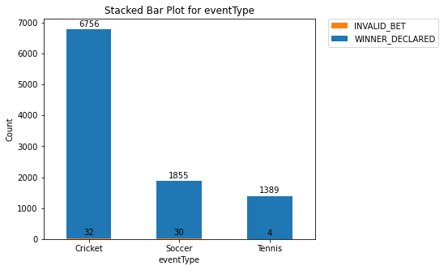

```python
crosstab_by_y_plot(merged_data, 'eventType', figsize=(6,5))
```

### Observation :

- Most betting done on **cricket** eventType.
- **Soccer** eventType have high **INVALID_BETS** relatively comparing to others.

## 2.5.1.6 Feature Analysis : userName

```python
merged_data['userName'].nunique()
```

```
410
```

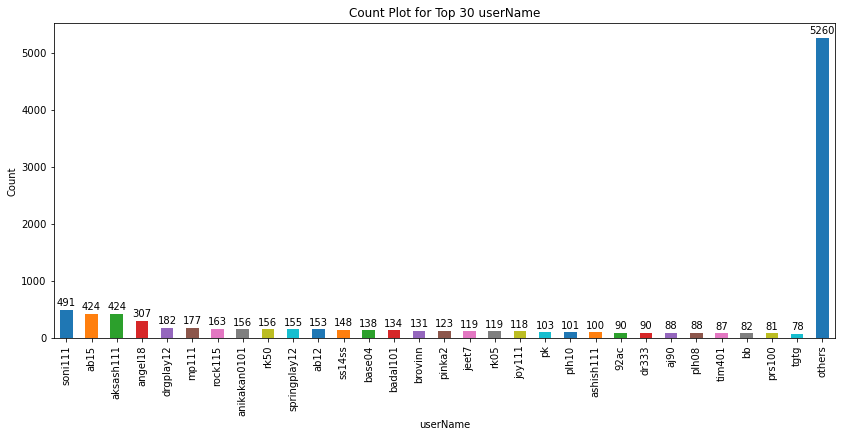

```python
count_plot(merged_data, 'userName')
```

### Observation :

- **No any extreme user** exist in the data who place bets **extremely higher than the others**.

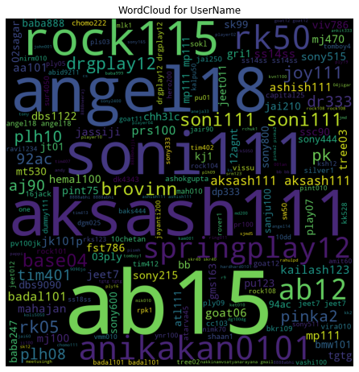

```python
word_list = []
import matplotlib.pyplot as plt
from wordcloud import WordCloud, STOPWORDS

for val in merged_data.userName:
    val = str(val).strip().replace(" ", "_")
    word_list.append(val)

# Converts each token into lowercase
for i in range(len(word_list)):
    word_list[i] = word_list[i].lower()

wc = ' '.join(str(e) for e in word_list)

wordcloud = WordCloud(width = 800, height = 800,
            background_color ='black',
            min_font_size = 10).generate(wc)

# plot the WordCloud image
plt.figure(figsize = (6, 6), facecolor = None)
plt.imshow(wordcloud)
plt.axis("off")
plt.tight_layout(pad = 0)

plt.title("WordCloud for UserName")
plt.show()
```

### Observation :

- **ab15, soni111, aksash111, angel18, rock115** are some userName who placed high number of bets.
- Since **userName** is a **unique identifier** and should not to be use for modeling,
- But it can be very **useful**
  - if **userName** are fixed in the system where users are fixed (means we have fixed number of users), which is not a practical case.
  - OR use **userName** as **categorical feature** for only those **userName** who have certain **threshold**
    - consider them as important users.
    - and they are **active** in the system.
    - Then we can use **userName** for **future prediction** of them.
  - **userName** can provide help in prediction of that particular user for future bets.

## 2.5.1.7 Feature Analysis : selectionName

```python
merged_data.selectionName.nunique()
```

```
318
```

```python
crosstab_by_y_table(merged_data, 'selectionName', top=10, y_both=True)
```

```
-------------------------------------------------------
Top 10 selectionName by WINNER_DECLARED and INVALID_BET
-------------------------------------------------------
```

| status selectionName | INVALID_BET | WINNER_DECLARED |
| --- | --- | --- |
| Dolphins | 0 | 1228 |
| Islamabad United | 0 | 751 |
| Titans | 0 | 717 |
| Lions | 2 | 573 |
| Lahore Qalandars | 0 | 531 |
| Karachi Kings | 0 | 412 |
| Australia | 0 | 404 |
| Leeward Islands | 0 | 369 |
| New Zealand | 0 | 343 |
| Guyana | 0 | 284 |

| status selectionName | INVALID_BET | WINNER_DECLARED |
| --- | --- | --- |
| West Indies | 13 | 0 |
| Over 1.5 Goals | 7 | 38 |
| The Draw | 6 | 267 |
| Canterbury | 3 | 0 |
| Hugo Dellien | 3 | 0 |
| Sunrisers Hyderabad | 3 | 0 |
| Delhi Capitals | 3 | 0 |
| Werder Bremen | 2 | 0 |
| Pakistan | 2 | 0 |
| Over 2.5 Goals | 2 | 163 |

### Observation :

- selectionName **Dolphins** have highest and all **WINNER_DECLARED**.
- selectionName **West Indies** have only **13 bets** and **all of them are INVALID_BET**.

## 2.5.1.8 Feature Analysis : marketName

```python
heading('Unique marketNames :')
print(merged_data['marketName'].unique())
```

```
--------------------
Unique marketNames :
--------------------
['Match Odds' 'Tied Match' 'Over/Under 2.5 Goals' 'Over/Under 3.5 Goals'
 'Over/Under 1.5 Goals' 'Over/Under 4.5 Goals' 'Over/Under 5.5 Goals'
 'Over/Under 0.5 Goals' 'Over/Under 6.5 Goals' 'Over/Under 7.5 Goals']
```

```
----------------------------------
marketName grouped by status Count
----------------------------------
```

| status marketName | INVALID_BET | WINNER_DECLARED |
| --- | --- | --- |
| Match Odds | 55 | 9127 |
| Over/Under 0.5 Goals | 0 | 62 |
| Over/Under 1.5 Goals | 7 | 61 |
| Over/Under 2.5 Goals | 3 | 311 |
| Over/Under 3.5 Goals | 0 | 130 |
| Over/Under 4.5 Goals | 0 | 29 |
| Over/Under 5.5 Goals | 0 | 19 |
| Over/Under 6.5 Goals | 0 | 2 |
| Over/Under 7.5 Goals | 1 | 0 |
| Tied Match | 0 | 259 |

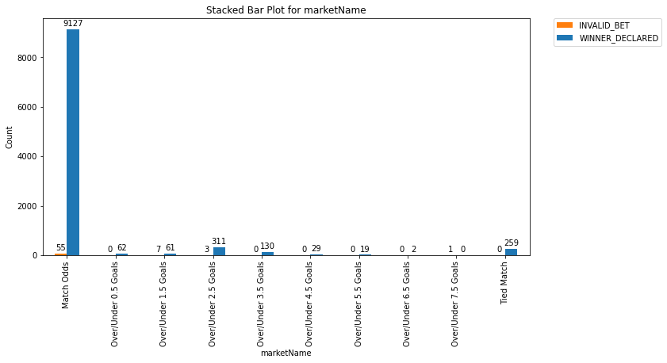

```python
crosstab_by_y_plot(merged_data, 'marketName', stacked=False, rotation=90, figsize=(11,5.5))
```

### Observation :

- Most bets are marketName **Match Odds**.
- **Tied Match** marketName does not have any **INVALID_BET** while it have total **259** bets.

## 2.5.1.9 Feature Analysis : event

```python
merged_data['event'].nunique()
```

```
245
```

```python
# count_plot(merged_data, 'event')
```

```python
crosstab_by_y_table(merged_data, 'event', y_both=True)
```

```
-----------------------------------------------
Top 10 event by WINNER_DECLARED and INVALID_BET
-----------------------------------------------
```

| status event | INVALID_BET | WINNER_DECLARED |
| --- | --- | --- |
| Islamabad United v Multan Sultans | 0 | 967 |
| New Zealand v Australia (1st T20) | 0 | 766 |
| Lions v Warriors | 2 | 612 |
| Lahore Qalandars v Peshawar Zalmi | 0 | 561 |
| Guyana v Trinidad & Tobago | 0 | 557 |
| Dolphins v Cape Cobras | 0 | 553 |
| Leeward Islands v Jamaica | 0 | 470 |
| Warriors v Dolphins | 0 | 464 |
| Karachi Kings v Quetta Gladiators | 0 | 427 |
| Titans v Knights | 0 | 412 |

| status event | INVALID_BET | WINNER_DECLARED |
| --- | --- | --- |
| Bangladesh v West Indies | 14 | 0 |
| Pakistan v South Africa | 5 | 0 |
| Hapoel Beer Sheva v Nice | 5 | 0 |
| Delhi Capitals v Royal Challengers Bangalore | 3 | 0 |
| Sunrisers Hyderabad v Mumbai Indians | 3 | 0 |
| Central Districts v Canterbury | 3 | 0 |
| Casanova v Dellien | 3 | 0 |
| US Cremonese v Brescia | 2 | 0 |
| Lions v Warriors | 2 | 612 |
| Werder Bremen v Schalke 04 | 2 | 0 |

## Observation :

- There are **some events** for which all bets are **INVALID_BET**.
- This feature should be included if these events are occurring in the future too.

## 2.5.1.9 Feature Analysis : winnerId

```python
merged_data['winnerId'].nunique()
```

```
195
```

```python
crosstab_by_y_table(merged_data, 'winnerId', y_both=True)
```

```
--------------------------------------------------
Top 10 winnerId by WINNER_DECLARED and INVALID_BET
--------------------------------------------------
```

| status winnerId | INVALID_BET | WINNER_DECLARED |
| --- | --- | --- |
| 4294273 | 0 | 1329 |
| 10782589 | 0 | 889 |
| 1254317 | 0 | 758 |
| 448 | 0 | 747 |
| 2312313 | 0 | 672 |
| 4294272 | 2 | 587 |
| 2810072 | 0 | 557 |
| 10782634 | 0 | 538 |
| 58805 | 9 | 427 |
| 10782635 | 0 | 420 |

| status winnerId | INVALID_BET | WINNER_DECLARED |
| --- | --- | --- |
| 235 | 14 | 0 |
| 58805 | 9 | 427 |
| 7461 | 5 | 0 |
| 1221385 | 5 | 46 |
| 22121561 | 3 | 0 |
| 86363 | 3 | 0 |
| 8226987 | 3 | 0 |
| 7671296 | 3 | 0 |
| 4294272 | 2 | 587 |
| 1221386 | 2 | 15 |

### Observation :

- Since **winnerId** is seems **unique Id's**, this feature should not include in the modeling.
- Here we have **195 unique winnerId's** in data.
- If we want to capture information from this feature for important winnerId's like most WINNER_DECLARED or most INALID_BET, we can perform modifiedc one hot encodeing for this feature with only those important winnerId's and discarding all others in one hot encoding.

## 2.5.2 Numerical Features Analysis

## 2.5.2.1 Feature Analysis : stake

```python
describe(merged_data['stake'])
```

```
----------------------
Descriptive statistics
----------------------
```

|  | count | mean | std | min | 25% | 50% | 75% | max | skew | kurt |
| --- | --- | --- | --- | --- | --- | --- | --- | --- | --- | --- |
| stake | 10066.000 | 31709.479 | 145600.465 | 9.000 | 400.000 | 2000.000 | 20000.000 | 9300000.000 | 31.301 | 1723.736 |

### Observation :

- **stake :**
  - have **high standard deviation**.
    - Low **standard deviation means** data are clustered around the **mean**, and **high standard deviation** indicates data are more spread out.
  - have **high positive skew value**, indicates **trail dragging towards the right** in their respective distributions.
  - have **high positive kurt value**, as **trail higher kurtosis** corresponds to **greater extremity of deviations (or outliers)**.

```
----------------------
PDF-CDF Plot for stake
----------------------
```

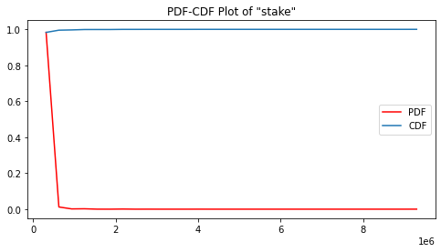

```python
pdf_cdf(merged_data, 'stake', bins=30,figsize=(8,4))
```

### Observation :

```
----------------------------------
Box Plot and Violin Plot for stake
----------------------------------
```

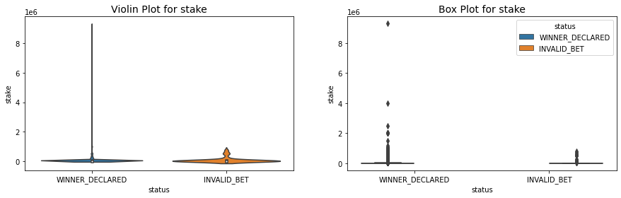

```python
box_violin_plot(merged_data, 'stake')
```

### Observation :

- **Distribution of stake** for **WINNER_DECLARED** and **INVALID_BET** are **skewed** and seems **similar**.
- **Box plot** shows there are some **outliers** in the stake feature.

```
-----------------------
Distribution Plot stake
-----------------------
```

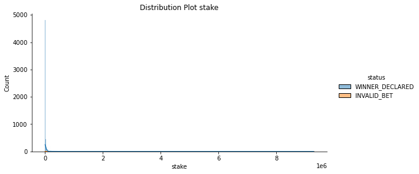

```
Wall time: 30.9 s
```

```python
%%time
displot(merged_data, 'stake')
```

### Observation :

- Hard to analyze by distribution plot because of high std deviation, skew and kurt.

#### Lets do more analysis for outliers

```python
#calculating 0-100th percentile to find a the correct percentile value for removal of outliers
for i in range(0,100,10):
    var =merged_data["stake"].values
    var = np.sort(var,axis = None)
    print("{} percentile value is {}".format(i,var[int(len(var)*(float(i)/100))]))
print ("100 percentile value is ",var[-1])
```

```
0 percentile value is 9.0
10 percentile value is 135.0
20 percentile value is 250.0
30 percentile value is 500.0
40 percentile value is 800.0
50 percentile value is 2000.0
60 percentile value is 10000.0
70 percentile value is 10000.0
80 percentile value is 25000.0
90 percentile value is 50000.0
100 percentile value is  9300000.0
```

```python
#looking further from the 99th percecntile
for i in range(90,100):
    var =merged_data["stake"].values
    var = np.sort(var,axis = None)
    print("{} percentile value is {}".format(i,var[int(len(var)*(float(i)/100))]))
print ("100 percentile value is ",var[-1])
```

```
90 percentile value is 50000.0
91 percentile value is 60000.0
92 percentile value is 100000.0
93 percentile value is 100000.0
94 percentile value is 100000.0
95 percentile value is 113000.0
96 percentile value is 200000.0
97 percentile value is 200000.0
98 percentile value is 300000.0
99 percentile value is 500000.0
100 percentile value is  9300000.0
```

### Observation :

    to make it normal distribution.

### Log Transform - stake

```python
#converting the values to log-values to chec for log-normal
import math
merged_data['stake_log']=[math.log(i) for i in merged_data['stake'].values]
```

```python
describe(merged_data[['stake','stake_log']]).T
```

```
----------------------
Descriptive statistics
----------------------
```

|  | count | mean | std | min | 25% | 50% | 75% | max | skew | kurt |
| --- | --- | --- | --- | --- | --- | --- | --- | --- | --- | --- |
| stake | 10066.000 | 31709.479 | 145600.465 | 9.000 | 400.000 | 2000.000 | 20000.000 | 9300000.000 | 31.301 | 1723.736 |
| stake_log | 10066.000 | 7.854 | 2.419 | 2.197 | 5.991 | 7.601 | 9.903 | 16.046 | 0.204 | -0.916 |

### Observation :

- **Log transform** have **lower standard deviation, skew, kurtosis** as compare to stake.
- **stake's log transform** should be **more similar** to **normal distribution** as compare to stake's distribution

```
--------------------------
PDF-CDF Plot for stake_log
--------------------------
```

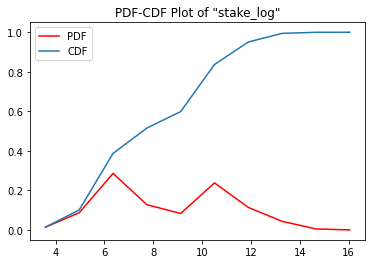

```python
pdf_cdf(merged_data, 'stake_log')
```

### Observation :

- stake_log have **bimodal** distribution.

```
--------------------------------------
Box Plot and Violin Plot for stake_log
--------------------------------------
```

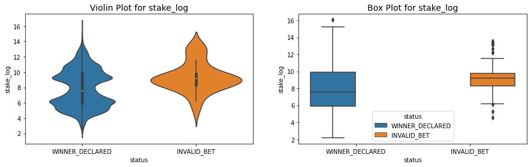

```python
box_violin_plot(merged_data, 'stake_log')
```

### Observation :

- **Violin Plot** shows **WINNER_DECLARED** and **INVALID_BET** **distribution** are **overlapping**, so this feature **alone** may not be able to good for prediction but can be helpful with other features.
- **Box Plot** shows there are some **outliers**.

```
---------------------------
Distribution Plot stake_log
---------------------------
```

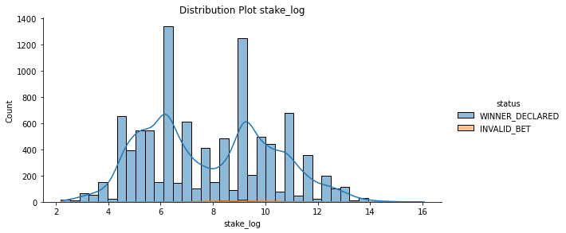

```python
displot(merged_data, 'stake_log')
```

### Observation :

- **stake_log distribution** is more similar to **normal distribution** as compare to stake and it is bimodal.

### QQ Plot:

- A **Q–Q (Quantile-Quantile) plot** is a **probability plot**, which is a **graphical method** for **comparing two probability distributions** by plotting their **quantiles** against each other.

```
-----------------------------------------------------------------------------
QQ Plot to check the stake_log distribution is similar to normal distribution
-----------------------------------------------------------------------------
```

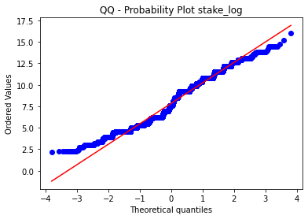

```python
qqPlot(merged_data, 'stake_log')
```

### Observation :

- **stake log transform (stake_log feature)** is **almost normal distribution**.

### BoxCox Transform : stake

```python
# transform training data & save lambda value
fitted_data_stake, fitted_lambda_stake = stats.boxcox(merged_data['stake'] + 1) # Add 1 to be able to transform 0 values
```

```python
# fitted_data_stake
```

```python
fitted_lambda_stake
```

```
-0.0466345079709477
```

```python
merged_data['stake']
```

```
0          500.000
1         2100.000
2        25000.000
3          300.000
4          500.000
           ...
10061   500000.000
10062   500000.000
10063    10000.000
10064   100000.000
10065     5000.000
Name: stake, Length: 10066, dtype: float64
```

```python
inv_boxcox(fitted_data_stake, fitted_lambda_stake)-1
```

```
array([   500.,   2100.,  25000., ...,  10000., 100000.,   5000.])
```

```python
merged_data['stake_boxcox'] = fitted_data_stake
```

```python
describe(merged_data[['stake','stake_log','stake_boxcox']]).T
```

```
----------------------
Descriptive statistics
----------------------
```

|  | count | mean | std | min | 25% | 50% | 75% | max | skew | kurt |
| --- | --- | --- | --- | --- | --- | --- | --- | --- | --- | --- |
| stake | 10066.000 | 31709.479 | 145600.465 | 9.000 | 400.000 | 2000.000 | 20000.000 | 9300000.000 | 31.301 | 1723.736 |
| stake_log | 10066.000 | 7.854 | 2.419 | 2.197 | 5.991 | 7.601 | 9.903 | 16.046 | 0.204 | -0.916 |
| stake_boxcox | 10066.000 | 6.485 | 1.665 | 2.183 | 5.229 | 6.400 | 7.931 | 11.297 | 0.038 | -0.998 |

### Observation :

- **BoxCox Transform of stake (stake_boxcox)** have **lower standard deviation, skew and kurtosis** as compare to **stake** and **stake log transform (stake_log)**.

```
-----------------------------------------
Box Plot and Violin Plot for stake_boxcox
-----------------------------------------
```

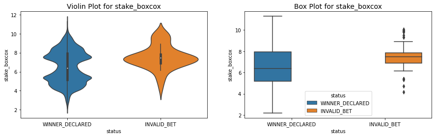

```python
box_violin_plot(merged_data, 'stake_boxcox')
```

### Observation :

- **BoxCox Transform of stake (stake_boxcox)** have **overlapping** **distribution between WINNER_DECLARED and INVALID_BET**.

```
------------------------------
Distribution Plot stake_boxcox
------------------------------
```

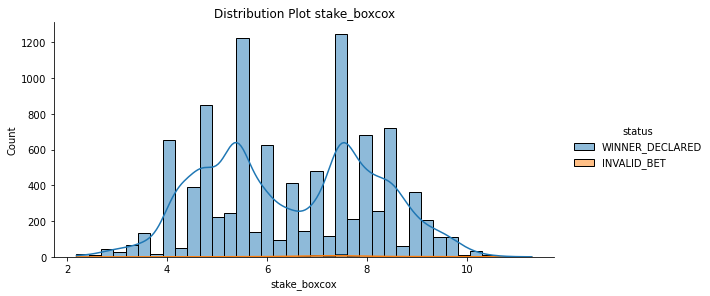

```python
displot(merged_data, 'stake_boxcox')
```

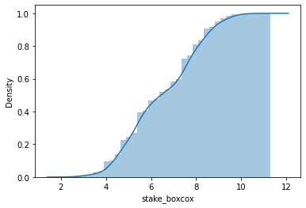

```python
kwargs = {'cumulative': True}
sns.distplot(merged_data['stake_boxcox'], hist_kws=kwargs, kde_kws=kwargs)
```

### Observation :

- **BoxCox Transform of stake (stake_boxcox)** have is more likely to **normal distribution** as compare to **stake feature distribution**.

```
--------------------------------------------------------------------------------
QQ Plot to check the stake_boxcox distribution is similar to normal distribution
--------------------------------------------------------------------------------
```

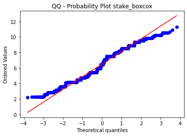

```python
qqPlot(merged_data, 'stake_boxcox')
```

### Observation :

- QQ Plot shows **BoxCox Transform of stake (stake_boxcox)** have is more likely to **normal distribution**.

## 2.5.2.2 Feature Analysis : betRate

```python
describe(merged_data['betRate'])
```

```
----------------------
Descriptive statistics
----------------------
```

|  | count | mean | std | min | 25% | 50% | 75% | max | skew | kurt |
| --- | --- | --- | --- | --- | --- | --- | --- | --- | --- | --- |
| betRate | 10066.000 | 2.452 | 13.855 | 1.010 | 1.180 | 1.400 | 1.670 | 1000.000 | 44.571 | 2835.808 |

### Observation :

- **High skew and high kurtosis.**

```
------------------------------------
Box Plot and Violin Plot for betRate
------------------------------------
```

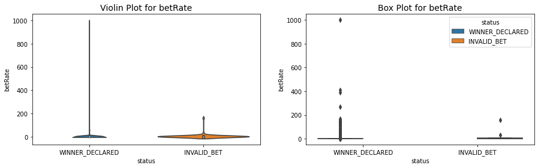

```python
box_violin_plot(merged_data, 'betRate')
```

```
-------------------------
Distribution Plot betRate
-------------------------
```

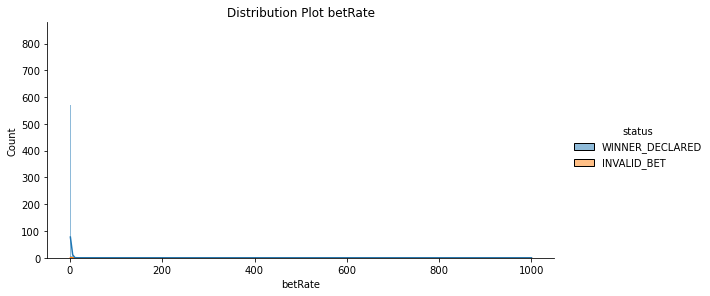

```
Wall time: 2min 35s
```

```python
%%time
displot(merged_data, 'betRate')
```

### Observation :

- **betRate** distribution is **extremely skewed**.
- Need to perform **Log transformation** and **BoxCox transformation** to make it close to **normal distribution**.

### Log transform : betRate

```python
merged_data['betRate_log'] = np.log(merged_data['betRate'])
```

```python
describe(merged_data[['betRate','betRate_log']]).T
```

```
----------------------
Descriptive statistics
----------------------
```

|  | count | mean | std | min | 25% | 50% | 75% | max | skew | kurt |
| --- | --- | --- | --- | --- | --- | --- | --- | --- | --- | --- |
| betRate | 10066.000 | 2.452 | 13.855 | 1.010 | 1.180 | 1.400 | 1.670 | 1000.000 | 44.571 | 2835.808 |
| betRate_log | 10066.000 | 0.425 | 0.515 | 0.010 | 0.166 | 0.336 | 0.513 | 6.908 | 4.969 | 33.523 |

### Observation :

- **betRate Log transformation** have **lower skew and kurt** as compare to betRate.

```
-----------------------------
Distribution Plot betRate_log
-----------------------------
```

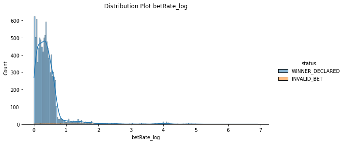

```python
displot(merged_data, 'betRate_log')
```

### Observation :

- **betRate Log transformation** distribution is still right skewed.

```
-------------------------------------------------------------------------------
QQ Plot to check the betRate_log distribution is similar to normal distribution
-------------------------------------------------------------------------------
```

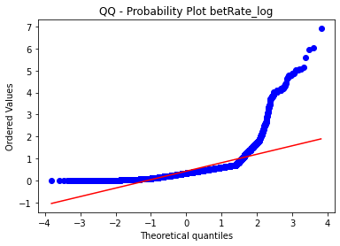

```python
qqPlot(merged_data, 'betRate_log')
```

### Observation :

- QQ Plot shows **betRate_log** is less likely to normal distribution.

### Boxcox Transformation : betRate

```python
# transform training data & save lambda value
fitted_data_betRate, fitted_lambda_betRate = stats.boxcox(merged_data['betRate'])
```

```python
# fitted_data_betRate
```

```python
fitted_lambda_betRate
```

```
-1.6678009857211833
```

```python
merged_data['betRate_boxcox'] = fitted_data_betRate
```

```python
describe(merged_data[['betRate', 'betRate_log', 'betRate_boxcox']]).T
```

```
----------------------
Descriptive statistics
----------------------
```

|  | count | mean | std | min | 25% | 50% | 75% | max | skew | kurt |
| --- | --- | --- | --- | --- | --- | --- | --- | --- | --- | --- |
| betRate | 10066.000 | 2.452 | 13.855 | 1.010 | 1.180 | 1.400 | 1.670 | 1000.000 | 44.571 | 2835.808 |
| betRate_log | 10066.000 | 0.425 | 0.515 | 0.010 | 0.166 | 0.336 | 0.513 | 6.908 | 4.969 | 33.523 |
| betRate_boxcox | 10066.000 | 0.251 | 0.137 | 0.010 | 0.145 | 0.257 | 0.345 | 0.600 | 0.246 | -0.350 |

### Observation :

- **betRate_boxcox** have **lower standard deviation, skew and kurtosis** as compare to **betRate and betRate_log**.

```
--------------------------------
Distribution Plot betRate_boxcox
--------------------------------
```

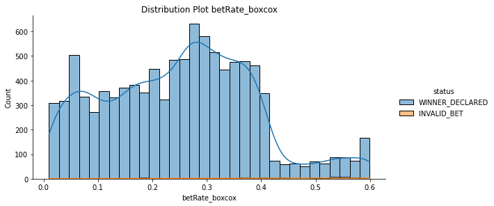

```python
displot(merged_data,'betRate_boxcox', hue='status', kde=True)
```

```
----------------------------------------------------------------------------------
QQ Plot to check the betRate_boxcox distribution is similar to normal distribution
----------------------------------------------------------------------------------
```

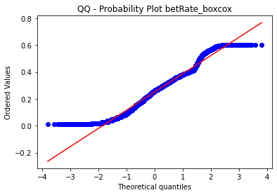

```python
qqPlot(merged_data, 'betRate_boxcox')
```

## 2.5.2.3 Feature Analysis : averagePriceMatched

```python
merged_data['averagePriceMatched'].nunique()
```

```
726
```

```python
describe(merged_data['averagePriceMatched'])
```

```
----------------------
Descriptive statistics
----------------------
```

|  | count | mean | std | min | 25% | 50% | 75% | max | skew | kurt |
| --- | --- | --- | --- | --- | --- | --- | --- | --- | --- | --- |
| averagePriceMatched | 10066.000 | 2.466 | 13.969 | 1.010 | 1.180 | 1.400 | 1.670 | 1000.000 | 43.882 | 2754.245 |

### Observation :

- **averagePriceMatched** also have **high skew and high kurt.**

```
-------------------------------------
Distribution Plot averagePriceMatched
-------------------------------------
```

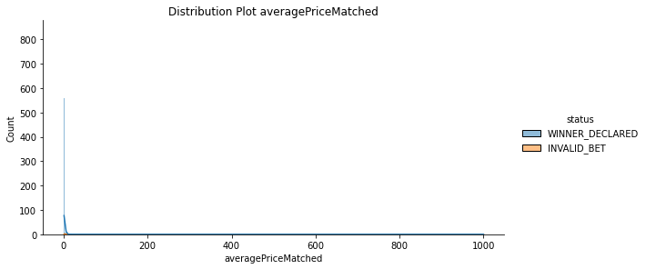

```
Wall time: 2min 50s
```

```python
%%time
displot(merged_data, 'averagePriceMatched')
```

### Observation :

- **averagePriceMatched** distribution is **extremely skewed.**
- Need **Log or BoxCox Transformation.**

### Log transformation : averagePriceMatched

```python
merged_data['averagePriceMatched_log'] = np.log(merged_data['averagePriceMatched'])
```

```python
describe(merged_data[['averagePriceMatched','averagePriceMatched_log']]).T
```

```
----------------------
Descriptive statistics
----------------------
```

|  | count | mean | std | min | 25% | 50% | 75% | max | skew | kurt |
| --- | --- | --- | --- | --- | --- | --- | --- | --- | --- | --- |
| averagePriceMatched | 10066.000 | 2.466 | 13.969 | 1.010 | 1.180 | 1.400 | 1.670 | 1000.000 | 43.882 | 2754.245 |
| averagePriceMatched_log | 10066.000 | 0.426 | 0.518 | 0.010 | 0.166 | 0.336 | 0.513 | 6.908 | 4.952 | 33.256 |

### Observation :

- **averagePriceMatched_log** have l**ower standard deviation, skew and kurt** in comparison to **averagePriceMatched**.

```
----------------------------------------------------
Box Plot and Violin Plot for averagePriceMatched_log
----------------------------------------------------
```

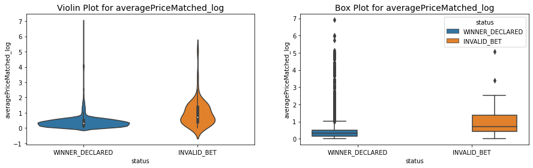

```python
box_violin_plot(merged_data, 'averagePriceMatched_log')
```

### Observation :

- **averagePriceMatched_log** **WINNER_DECLARED** and **INVALID_BET** distribution are **overlapping**.
- **averagePriceMatched_log** may have some outliers.

```
-----------------------------------------
Distribution Plot averagePriceMatched_log
-----------------------------------------
```

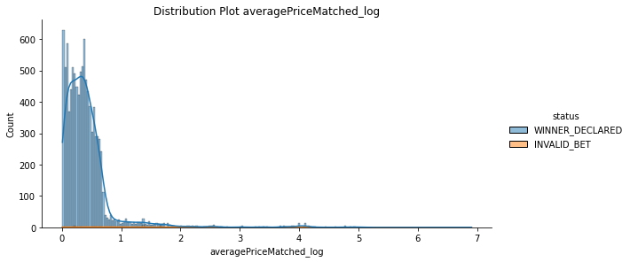

```python
displot(merged_data, 'averagePriceMatched_log')
```

### Observation :

- **averagePriceMatched_log** distribution is **right skewed.**

```
-------------------------------------------------------------------------------------------
QQ Plot to check the averagePriceMatched_log distribution is similar to normal distribution
-------------------------------------------------------------------------------------------
```

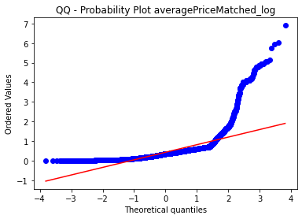

```python
qqPlot(merged_data, 'averagePriceMatched_log')
```